# R Notebook for Creditdata Analysis

#1 Installing required packages

```r
# Install tidyverse
install.packages("tidyverse")
# Install ISLR
install.packages("ISLR")
install.packages("caret")
# Load libraries
library(tidyverse)
library(ISLR)
```

```r
data("Credit")
```

```r
head(Credit,n=10)
```

```
##    ID  Income Limit Rating Cards Age Education Gender Student Married
## 1   1  14.891  3606    283     2  34        11   Male      No     Yes
## 2   2 106.025  6645    483     3  82        15 Female     Yes     Yes
## 3   3 104.593  7075    514     4  71        11   Male      No      No
## 4   4 148.924  9504    681     3  36        11 Female      No      No
## 5   5  55.882  4897    357     2  68        16   Male      No     Yes
## 6   6  80.180  8047    569     4  77        10   Male      No      No
## 7   7  20.996  3388    259     2  37        12 Female      No      No
## 8   8  71.408  7114    512     2  87         9   Male      No      No
## 9   9  15.125  3300    266     5  66        13 Female      No      No
## 10 10  71.061  6819    491     3  41        19 Female     Yes     Yes
##           Ethnicity Balance
## 1         Caucasian     333
## 2             Asian     903
## 3             Asian     580
## 4             Asian     964
## 5         Caucasian     331
## 6         Caucasian    1151
## 7  African American     203
## 8             Asian     872
## 9         Caucasian     279
## 10 African American    1350
```

```r
summary(Credit)
```

```
##        ID            Income           Limit           Rating
##  Min.   :  1.0   Min.   : 10.35   Min.   :  855   Min.   : 93.0
##  1st Qu.:100.8   1st Qu.: 21.01   1st Qu.: 3088   1st Qu.:247.2
##  Median :200.5   Median : 33.12   Median : 4622   Median :344.0
##  Mean   :200.5   Mean   : 45.22   Mean   : 4736   Mean   :354.9
##  3rd Qu.:300.2   3rd Qu.: 57.47   3rd Qu.: 5873   3rd Qu.:437.2
##  Max.   :400.0   Max.   :186.63   Max.   :13913   Max.   :982.0
##      Cards            Age          Education        Gender    Student
##  Min.   :1.000   Min.   :23.00   Min.   : 5.00    Male :193   No :360
##  1st Qu.:2.000   1st Qu.:41.75   1st Qu.:11.00   Female:207   Yes: 40
##  Median :3.000   Median :56.00   Median :14.00
##  Mean   :2.958   Mean   :55.67   Mean   :13.45
##  3rd Qu.:4.000   3rd Qu.:70.00   3rd Qu.:16.00
##  Max.   :9.000   Max.   :98.00   Max.   :20.00
##  Married              Ethnicity      Balance
##  No :155   African American: 99   Min.   :   0.00
##  Yes:245   Asian           :102   1st Qu.:  68.75
##            Caucasian       :199   Median : 459.50
##                                   Mean   : 520.01
##                                   3rd Qu.: 863.00
##                                   Max.   :1999.00
```

#1.a. Drop ID column

```r
# Load the tidyverse package
library(tidyverse)

# Drop the "ID" column using dplyr
Credit <- Credit %>% select(-ID)
```

```r
head(Credit,n=10)
```

```
##     Income Limit Rating Cards Age Education Gender Student Married
## 1   14.891  3606    283     2  34        11   Male      No     Yes
## 2  106.025  6645    483     3  82        15 Female     Yes     Yes
## 3  104.593  7075    514     4  71        11   Male      No      No
## 4  148.924  9504    681     3  36        11 Female      No      No
## 5   55.882  4897    357     2  68        16   Male      No     Yes
## 6   80.180  8047    569     4  77        10   Male      No      No
## 7   20.996  3388    259     2  37        12 Female      No      No
## 8   71.408  7114    512     2  87         9   Male      No      No
## 9   15.125  3300    266     5  66        13 Female      No      No
## 10  71.061  6819    491     3  41        19 Female     Yes     Yes
##           Ethnicity Balance
## 1         Caucasian     333
## 2             Asian     903
## 3             Asian     580
## 4             Asian     964
## 5         Caucasian     331
## 6         Caucasian    1151
## 7  African American     203
## 8             Asian     872
## 9         Caucasian     279
## 10 African American    1350
```

#Data Cleaning

```r
sum(is.na(Credit))
```

```
## [1] 0
```

There are no null values in this data

# Handling Outliers

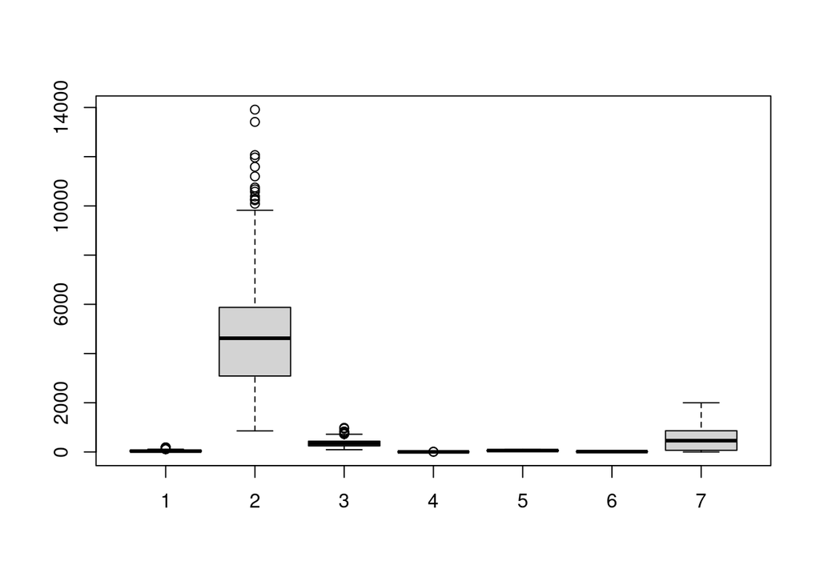

```r
boxplot(Credit$Income,Credit$Limit,Credit$Rating,Credit$Cards,Credit$Age,Credit$Education,Credit$Balance)
```

As we can see there are outliers in this data

```r
iqr_inc <- IQR(Credit$Income)
iqr_limit <- IQR(Credit$Limit)
iqr_rating <- IQR(Credit$Rating)
iqr_cards <- IQR(Credit$Cards)
```

```r
# Calculate upper and lower bounds for each column
upper_inc<- quantile(Credit$Income, 0.75) + 1.5 * iqr_inc
lower_inc<- quantile(Credit$Income, 0.25) - 1.5 * iqr_inc
upper_rating<- quantile(Credit$Rating, 0.75) + 1.5 * iqr_rating
lower_rating<- quantile(Credit$Rating, 0.25) - 1.5 * iqr_rating
upper_limit<- quantile(Credit$Limit, 0.75) + 1.5 * iqr_limit
lower_limit<- quantile(Credit$Limit, 0.25) - 1.5 * iqr_limit
upper_cards<- quantile(Credit$Cards, 0.75) + 1.5 * iqr_cards
lower_cards<- quantile(Credit$Cards, 0.25) - 1.5 * iqr_cards
```

```r
# Remove outliers in each column
Credit <- Credit[Credit$Income >= lower_inc & Credit$Income <= upper_inc &
          Credit$Rating>= lower_rating & Credit$Rating <= upper_rating &
          Credit$Limit >= lower_limit &  Credit$Limit <= upper_limit &
          Credit$Cards>= lower_cards &  Credit$Cards <= upper_cards,]
```

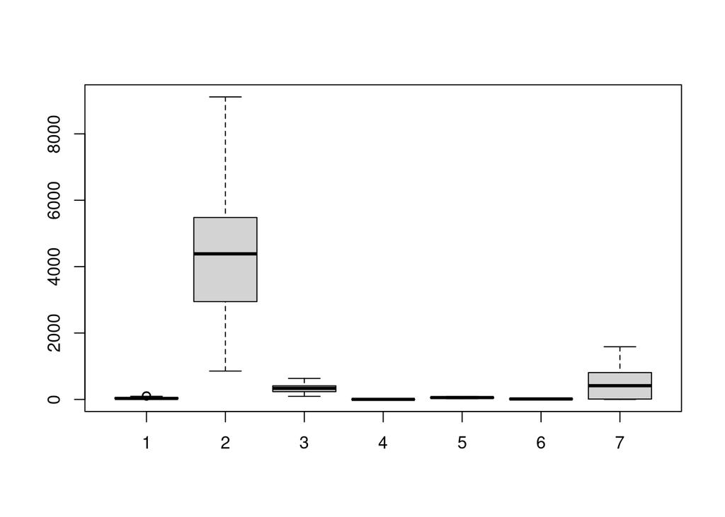

```r
boxplot(Credit$Income,Credit$Limit,Credit$Rating,Credit$Cards,Credit$Age,Credit$Education,Credit$Balance)
```

```r
#1.b.
# Task 1: Fit a multiple linear regression model
credit_lm <- lm(Balance ~ ., data = Credit)
summary(credit_lm)
```

```
##
## Call:
## lm(formula = Balance ~ ., data = Credit)
##
## Residuals:
##     Min      1Q  Median      3Q     Max
## -178.16  -76.06  -10.12   58.57  300.42
##
## Coefficients:
##                      Estimate Std. Error t value Pr(>|t|)
## (Intercept)        -446.73703   38.21555 -11.690  < 2e-16 ***
## Income               -8.13271    0.29655 -27.424  < 2e-16 ***
## Limit                 0.18219    0.03452   5.278 2.28e-07 ***
## Rating                1.19835    0.51622   2.321 0.020830 *
## Cards                16.69808    4.71979   3.538 0.000457 ***
## Age                  -0.55613    0.30873  -1.801 0.072487 .
## Education            -1.89107    1.67668  -1.128 0.260136
## GenderFemale        -11.22573   10.34066  -1.086 0.278394
## StudentYes          425.68977   17.77551  23.948  < 2e-16 ***
## MarriedYes           -7.86336   10.79468  -0.728 0.466818
## EthnicityAsian       19.41151   14.74104   1.317 0.188741
## EthnicityCaucasian   20.08824   12.84292   1.564 0.118671
## ---
## Signif. codes:  0 '***' 0.001 '**' 0.01 '*' 0.05 '.' 0.1 ' ' 1
##
## Residual standard error: 98.65 on 356 degrees of freedom
## Multiple R-squared:  0.9463, Adjusted R-squared:  0.9446
## F-statistic: 570.1 on 11 and 356 DF,  p-value: < 2.2e-16
```

#1.c. According to the Summary for feature selection and to examine the linearity we need to consider both the P values as well as coefficients. The features that have non zero coefficients and those that have significantly low p value show linearity with the target variable.

Income: The coefficient is -8.13271 and the p-value is < 2e-16, this shows significant negative relationship with the response variable.

Limit: The estimate coefficient is 0.18219 and the p-value is 2.28e-0,shows significant positive relationship with the response variable.

Rating: The estimate coefficient is 1.19835 and the p-value is 0.020830 shows a significant positive relationship with the response variable.

Cards: The estimate coefficient is 16.69808 and the p-value is 0.000457 shows a positive relationship with the response variable.

Student: The estimate coefficient is 425.68977 and the p-value is < 2e-16 indicating a significant positive relationship with the response variable.

The selected features are: 1. Income 2. Limit 3. Rating 4. Cards 5. Student

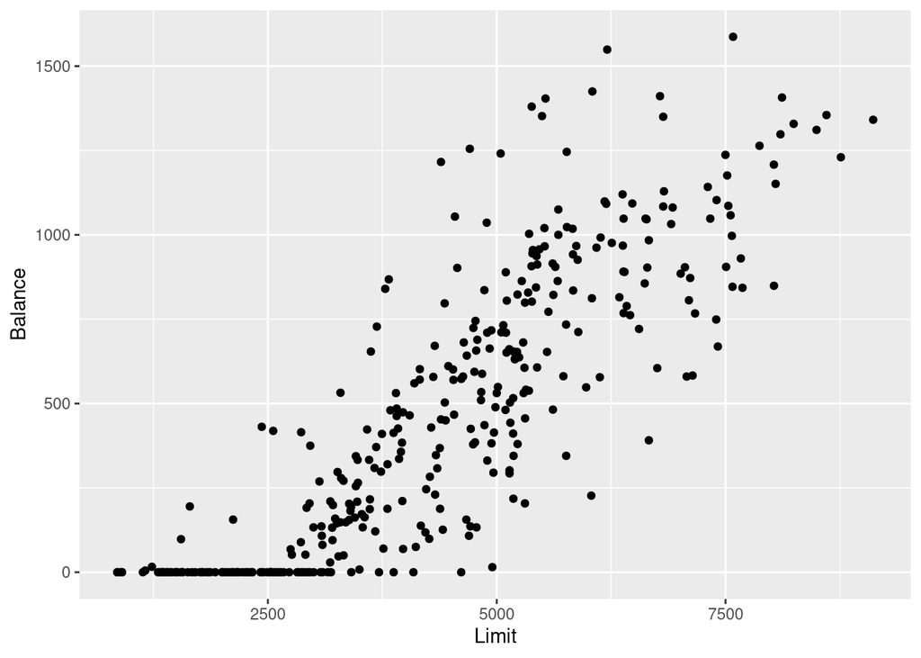

```r
# Scatter plot
ggplot(Credit, aes(x = Limit, y = Balance)) +
  geom_point() +
  labs(
    x = "Limit",
    y = "Balance"
  )
```

#Selecting Features

```r
selected_features <- c("Income", "Limit", "Rating","Cards","Student")
```

#Linear Regression model

```r
library(caret)
set.seed(123)
split_data <- createDataPartition(Credit$Balance, p = 0.7, list = FALSE)
train_data <- Credit[split_data, ]
test_data <- Credit[-split_data, ]
```

```r
model <- lm(Balance ~ ., data = train_data[, c("Balance", selected_features)])
```

```r
summary(model)
```

```
##
## Call:
## lm(formula = Balance ~ ., data = train_data[, c("Balance", selected_features)])
##
## Residuals:
##     Min      1Q  Median      3Q     Max
## -208.10  -74.08   -8.43   59.85  315.24
##
## Coefficients:
##               Estimate Std. Error t value Pr(>|t|)
## (Intercept) -514.17628   25.86122 -19.882  < 2e-16 ***
## Income        -8.26243    0.33241 -24.856  < 2e-16 ***
## Limit          0.18139    0.03982   4.555 8.13e-06 ***
## Rating         1.26154    0.59599   2.117  0.03526 *
## Cards         16.78103    5.30336   3.164  0.00174 **
## StudentYes   442.07011   21.05411  20.997  < 2e-16 ***
## ---
## Signif. codes:  0 '***' 0.001 '**' 0.01 '*' 0.05 '.' 0.1 ' ' 1
##
## Residual standard error: 97.7 on 254 degrees of freedom
## Multiple R-squared:  0.9488, Adjusted R-squared:  0.9478
## F-statistic: 941.1 on 5 and 254 DF,  p-value: < 2.2e-16
```

```r
predicted_values <- predict(model, newdata = test_data)
```

```r
rmse <- sqrt(mean((predicted_values - test_data$Balance)^2))

r_squared <- 1 - sum((predicted_values - test_data$Balance)^2) / sum((test_data$Balance - mean(test_data$Balance))^2)
cat("Model Performance: RMSE =", rmse, "R-squared =", r_squared, "\n")
```

```
## Model Performance: RMSE = 103.0631 R-squared = 0.9330829
```

#1.d. For a model to be better fitting linear regression model it should have a low RMSE value and a greater R_squared value. This shows the model predictions are close to the actual values. Here the R_ squared value ranges from 0 to 1 O means the model doesn’t explain variability 1 means the model explains variability well. As there is 0.93 which means 93% the model explains variability of data well. It also has Low RMSE comparitively.

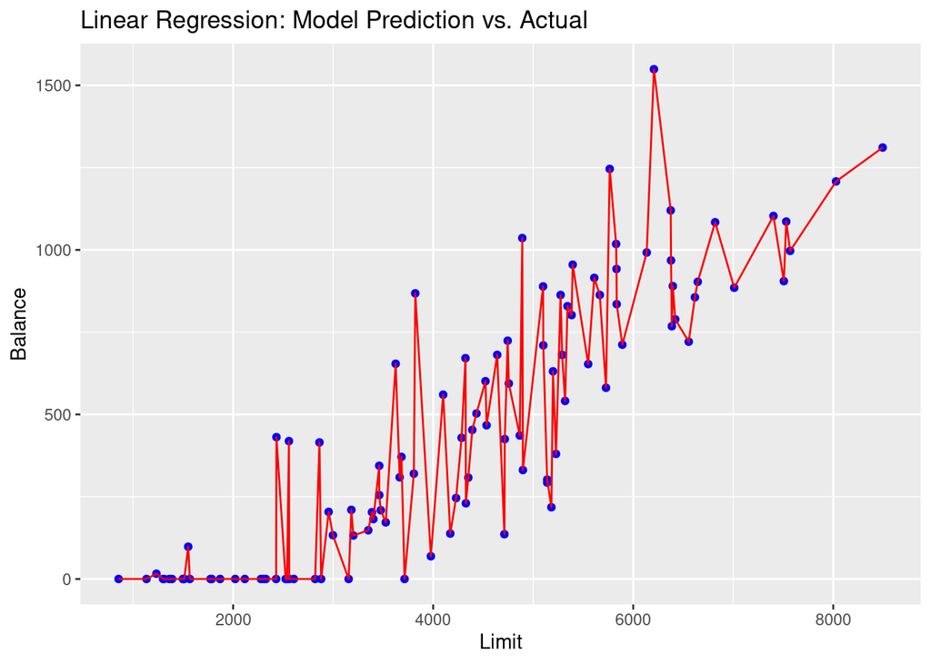

```r
ggplot() +
  geom_point(data = test_data, aes(x = Limit, y = Balance), color = "blue") +
  geom_line(data = test_data, aes(x = Limit, y = Balance), color = "red") +
  xlab("Limit") +
  ylab("Balance") +
  ggtitle("Linear Regression: Model Prediction vs. Actual")
```

[figure not shown]

```r
ggplot(test_data, aes(x = Balance, y = predicted_values)) +
  geom_point() +
  geom_abline(intercept = 0, slope = 1, color = "red", linetype = "dashed") +
  labs(x = "Actual Energy Usage (kWh)", y = "Predicted Energy Usage (kWh)") +
  ggtitle("Model Performance")
```

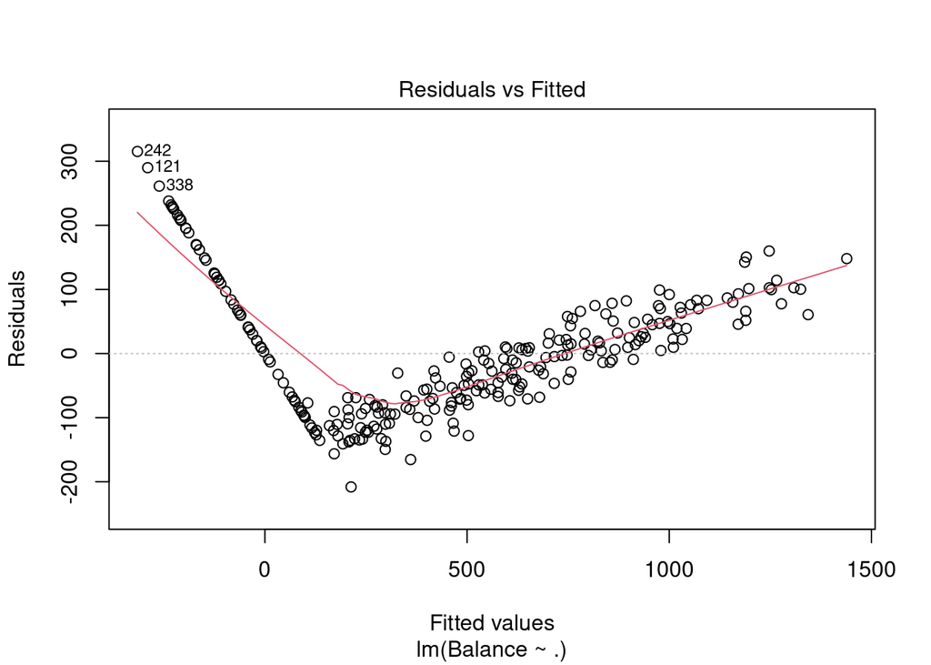

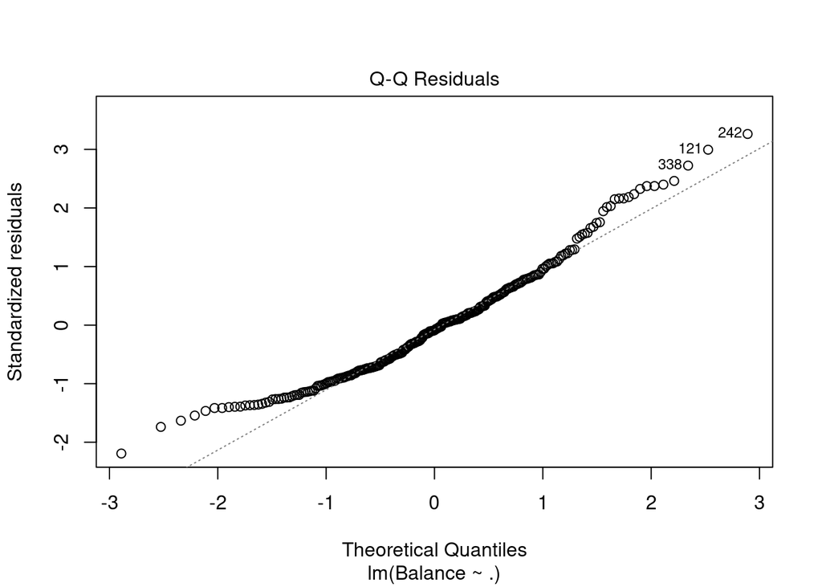

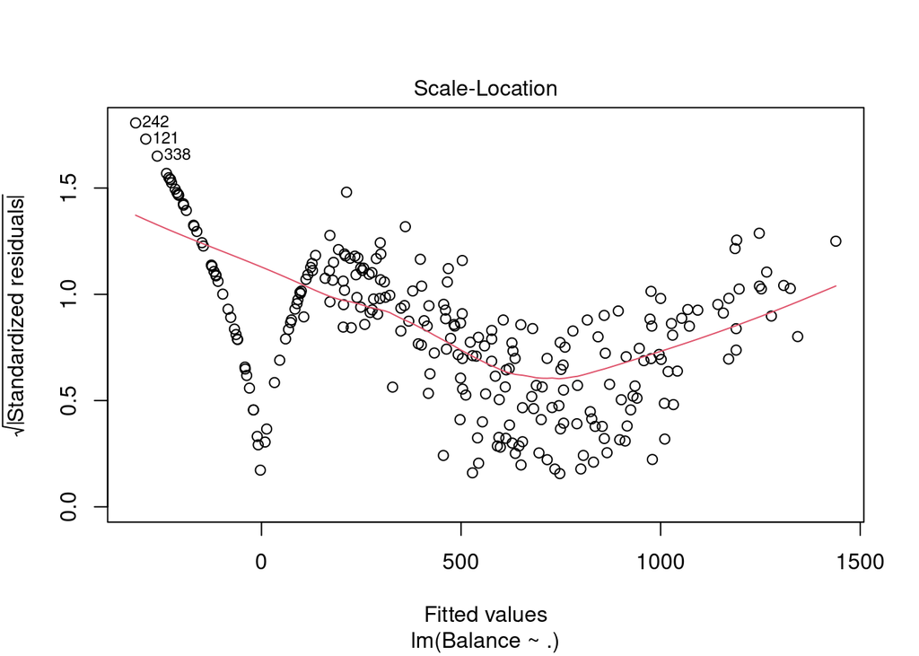

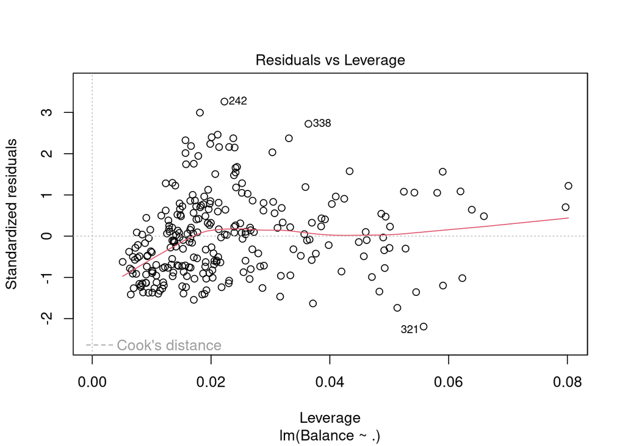

```r
plot(model)
```

```r
# Creating the new_data dataframe
new_data <- data.frame(
  Income = 50000,
  Limit = 5000,
  Rating = 700,
  Cards = 5,
  Student = factor("Yes", levels = c("No", "Yes"))
)
```

```r
# Display the modified new_data dataframe
new_data
```

```
##   Income Limit Rating Cards Student
## 1  50000  5000    700     5     Yes
```

```r
predicted_values <- predict(model, newdata = new_data, interval = "prediction", level = 0.95)
```

```r
mean_predicted_balance <- predicted_values[, "fit"]
```

```r
result <- data.frame(Mean = mean_predicted_balance)
result
```

```
##        Mean
## 1 -411319.6
```

```r
# Fit logistic regression model
logistic_model <- glm(Married ~ ., data = Credit, family = "binomial")
```

```r
# Print model summary
summary(logistic_model)
```

```
##
## Call:
## glm(formula = Married ~ ., family = "binomial", data = Credit)
##
## Coefficients:
##                      Estimate Std. Error z value Pr(>|z|)
## (Intercept)        -1.0891068  0.9597951  -1.135   0.2565
## Income             -0.0045877  0.0110709  -0.414   0.6786
## Limit              -0.0013872  0.0007688  -1.804   0.0712 .
## Rating              0.0244064  0.0112284   2.174   0.0297 *
## Cards              -0.1235209  0.1023472  -1.207   0.2275
## Age                -0.0110814  0.0066061  -1.677   0.0935 .
## Education           0.0576207  0.0358456   1.607   0.1080
## GenderFemale        0.0276854  0.2207558   0.125   0.9002
## StudentYes         -0.3686662  0.5997382  -0.615   0.5387
## EthnicityAsian      0.7065517  0.3148775   2.244   0.0248 *
## EthnicityCaucasian  0.3498402  0.2679739   1.306   0.1917
## Balance            -0.0008365  0.0011162  -0.749   0.4536
## ---
## Signif. codes:  0 '***' 0.001 '**' 0.01 '*' 0.05 '.' 0.1 ' ' 1
##
## (Dispersion parameter for binomial family taken to be 1)
##
##     Null deviance: 491.73  on 367  degrees of freedom
## Residual deviance: 474.38  on 356  degrees of freedom
## AIC: 498.38
##
## Number of Fisher Scoring iterations: 4
```

#3.a Based on this output:

The features “Rating” and “EthnicityAsian” have significant coefficients and are likely related to the probability of being married.(also indicated by stars).

From the provided output, the features that make an impact and thus related to the response (Married) are:

Rating: The coefficient estimate is 0.0244064, and it has a p-value of 0.0297.

EthnicityAsian: The coefficient estimate is 0.7065517, and it has a p-value of 0.0248.

These features have p-values less than the level of 0.05 which shows a higher probability of being married.

#3.b. The model appears to fit the training data better than the null model.For example

*Null Deviance:* The null deviance represents the deviance of the model with no predictors. Here, the null deviance is 491.73.

*Residual Deviance:* The residual deviance represents the deviance of the model with predictors. Here, the residual deviance is 474.38.

Therefore, the logistic regression model fits the training data better than the null model.

```r
predicted_classes <- predict(logistic_model, newdata = train_data, type = "response")
predicted_classes <- ifelse(predicted_classes > 0.5, 1, 0)
```

```r
# Create a confusion matrix
conf_matrix <- table(Actual = train_data$Married, Predicted = predicted_classes)
```

```r
print(conf_matrix)
```

```
##       Predicted
## Actual   0   1
##    No   24  80
##    Yes  20 136
```

True Positive (TP): 136 cases are correct, predicted as “Yes” (Married). True Negative (TN): 24 cases are correct, predicted as “No” (Not Married). False Positive (FP): 80 cases are incorrect ,predicted as “Yes” (Married). False Negative (FN): 20 cases are incorrect, predicted as “No” (Not Married). Hence the model doesn’t produce balanced classifications.

```r
# Calculate training accuracy
accuracy <- sum(diag(conf_matrix)) / sum(conf_matrix)
cat("Training Accuracy:", accuracy, "\n")
```

```
## Training Accuracy: 0.6153846
```

#4.c Hence the accuracy is 61.5%.This means that the model correctly predicts the marital status for about 61.5% right among the observations in the training data. We can see that the number of True positives are 136 where as True negative is 24 only.A balanced classification would have similar counts for TP and TN. Hence from the confusion matrix we can find that the model is moderately accurate.